# E-Wallets

## 1- Introduction

E-payments became more and more popular among users after the pandemic in 2020, which led to more investments in this sector. E-wallets represent a huge field in this sector. As shown below, e-wallets growth over the year 2020 is approx. 19.8%

Orange Cash, as a leading player in such field, is the main focus of this case study.

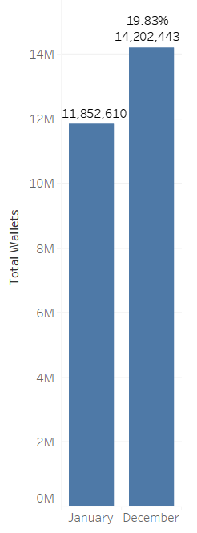

## 2- Dashboards

The following section aims to dig deeper into the data provided and report the findings visually to get some insights that might help in storytelling and recommendations.

### 1- Marketshare

This dashboard studies the Marketshare data among the 4 companies competing in this field (Vodafone, Orange, We, Etisalat).

```python
%%html
<div class='tableauPlaceholder' id='viz1697044153308' style='position: relative'><noscript><a href='#'><img alt='MarketShare Dashboard ' src='https:&#47;&#47;public.tableau.com&#47;static&#47;images&#47;Or&#47;OrangeCashData&#47;Marketshare&#47;1_rss.png' style='border: none' /></a></noscript><object class='tableauViz'  style='display:none;'><param name='host_url' value='https%3A%2F%2Fpublic.tableau.com%2F' /> <param name='embed_code_version' value='3' /> <param name='site_root' value='' /><param name='name' value='OrangeCashData&#47;Marketshare' /><param name='tabs' value='no' /><param name='toolbar' value='yes' /><param name='static_image' value='https:&#47;&#47;public.tableau.com&#47;static&#47;images&#47;Or&#47;OrangeCashData&#47;Marketshare&#47;1.png' /> <param name='animate_transition' value='yes' /><param name='display_static_image' value='yes' /><param name='display_spinner' value='yes' /><param name='display_overlay' value='yes' /><param name='display_count' value='yes' /><param name='language' value='en-US' /><param name='filter' value='publish=yes' /></object></div>                <script type='text/javascript'>                    var divElement = document.getElementById('viz1697044153308');                    var vizElement = divElement.getElementsByTagName('object')[0];                    if ( divElement.offsetWidth > 800 ) { vizElement.style.width='100%';vizElement.style.height=(divElement.offsetWidth*0.75)+'px';} else if ( divElement.offsetWidth > 500 ) { vizElement.style.width='100%';vizElement.style.height=(divElement.offsetWidth*0.75)+'px';} else { vizElement.style.width='100%';vizElement.style.height='1427px';}                     var scriptElement = document.createElement('script');                    scriptElement.src = 'https://public.tableau.com/javascripts/api/viz_v1.js';                    vizElement.parentNode.insertBefore(scriptElement, vizElement);                </script>
```

[figure not shown]

This dashboard shows the following KPIs regarding **Overall E-Wallet Providers' Transactions, Growth, and Market Share**:

```
1-Count of the total transactions processes carried out per month for each wallet provider.
2-New wallets per month for each wallet provider.
3-Count of the total wallets per month for each wallet provider.
4-Growth in wallets count over the year by measuring the difference between January and December data for wallets for each wallet provider.
5-Percentage of wallets among the market for each wallet provider.
```

### 2- Orange Cash payments

This dashboard looks more into Orange Cash detailed payments data.

```python
%%html
<div class='tableauPlaceholder' id='viz1697043902982' style='position: relative'><noscript><a href='#'><img alt='Orange cash payments ' src='https:&#47;&#47;public.tableau.com&#47;static&#47;images&#47;Or&#47;OrangeCashData&#47;Orangecashpayments&#47;1_rss.png' style='border: none' /></a></noscript><object class='tableauViz'  style='display:none;'><param name='host_url' value='https%3A%2F%2Fpublic.tableau.com%2F' /> <param name='embed_code_version' value='3' /> <param name='site_root' value='' /><param name='name' value='OrangeCashData&#47;Orangecashpayments' /><param name='tabs' value='no' /><param name='toolbar' value='yes' /><param name='static_image' value='https:&#47;&#47;public.tableau.com&#47;static&#47;images&#47;Or&#47;OrangeCashData&#47;Orangecashpayments&#47;1.png' /> <param name='animate_transition' value='yes' /><param name='display_static_image' value='yes' /><param name='display_spinner' value='yes' /><param name='display_overlay' value='yes' /><param name='display_count' value='yes' /><param name='language' value='en-US' /><param name='filter' value='publish=yes' /></object></div>                <script type='text/javascript'>                    var divElement = document.getElementById('viz1697043902982');                    var vizElement = divElement.getElementsByTagName('object')[0];                    if ( divElement.offsetWidth > 800 ) { vizElement.style.width='1520px';vizElement.style.minHeight='587px';vizElement.style.maxHeight='887px';vizElement.style.height=(divElement.offsetWidth*0.75)+'px';} else if ( divElement.offsetWidth > 500 ) { vizElement.style.width='1520px';vizElement.style.minHeight='587px';vizElement.style.maxHeight='887px';vizElement.style.height=(divElement.offsetWidth*0.75)+'px';} else { vizElement.style.width='100%';vizElement.style.height='1327px';}                     var scriptElement = document.createElement('script');                    scriptElement.src = 'https://public.tableau.com/javascripts/api/viz_v1.js';                    vizElement.parentNode.insertBefore(scriptElement, vizElement);                </script>
```

[figure not shown]

This dashboard shows the following KPIs regarding **Orange Cash Transactions Demographic Analysis**:

```
1-Classification of the total transactions processes carried out by each gender and age group using Orange Cash.
2-Total transactions amount carried out by each gender as per their district using Orange Cash.
3-Count of total transactions processes carried out by each gender as per their district using Orange Cash.
4-Count of new customers signing up for Orange Cash each month as per their gender.
```

### 3- Payment Details

This dashboard aims to dig deep into the payment details data among the 4 companies competing in this field (Vodafone, Orange, We, Etisalat).

```python
%%html
<div class='tableauPlaceholder' id='viz1697045907238' style='position: relative'><noscript><a href='#'><img alt='Payments Details ' src='https:&#47;&#47;public.tableau.com&#47;static&#47;images&#47;Or&#47;OrangeCashData&#47;PaymentsDetails&#47;1_rss.png' style='border: none' /></a></noscript><object class='tableauViz'  style='display:none;'><param name='host_url' value='https%3A%2F%2Fpublic.tableau.com%2F' /> <param name='embed_code_version' value='3' /> <param name='site_root' value='' /><param name='name' value='OrangeCashData&#47;PaymentsDetails' /><param name='tabs' value='no' /><param name='toolbar' value='yes' /><param name='static_image' value='https:&#47;&#47;public.tableau.com&#47;static&#47;images&#47;Or&#47;OrangeCashData&#47;PaymentsDetails&#47;1.png' /> <param name='animate_transition' value='yes' /><param name='display_static_image' value='yes' /><param name='display_spinner' value='yes' /><param name='display_overlay' value='yes' /><param name='display_count' value='yes' /><param name='language' value='en-US' /></object></div>                <script type='text/javascript'>                    var divElement = document.getElementById('viz1697045907238');                    var vizElement = divElement.getElementsByTagName('object')[0];                    if ( divElement.offsetWidth > 800 ) { vizElement.style.width='100%';vizElement.style.height=(divElement.offsetWidth*0.75)+'px';} else if ( divElement.offsetWidth > 500 ) { vizElement.style.width='100%';vizElement.style.height=(divElement.offsetWidth*0.75)+'px';} else { vizElement.style.width='100%';vizElement.style.height='777px';}                     var scriptElement = document.createElement('script');                    scriptElement.src = 'https://public.tableau.com/javascripts/api/viz_v1.js';                    vizElement.parentNode.insertBefore(scriptElement, vizElement);                </script>
```

[figure not shown]

This dashboard shows the following KPIs regarding **E-wallets Payments Categorized Analysis**:

```
1-the difference between cash in and cash out processes carried out by users per each company.
2-the categorization of each payment process carried out by users per each company.
```

## 3- Recommendations

1. As shown in the charts above, utilities bills are the least favorite payment type among users. This can be turned to Orange’s advantage in promoting such a service among its users as there’s no strong competition in this field.
2. Also, as it’s shown that the above 50s age group represent a huge percentage of Orange Cash users, they can be targeted to use the utilities bills payments in order to avoid the hassle of the offline payments process.
3. As Orange Cash is considered as a banking service for non-banking customers, so the districts of lower income can be motivated to use the service much more in order to establish a strong market share in non-covered areas.
4. Growth data for Orange Cash shows consistency over the year, which can’t be considered as a good indication taking into consideration that other competitors achieve more growth over the year. Therefore, encouraging more customers to open new wallets is a huge necessity. This can be done by targeting the age groups which represent the most common Orange Cash users.